# DA5030 Practicum 3

Jiaming Xu

Mar 30, 2022

# Problem 1.

### 1. Importing data set and pre-process data.

```r
library(tidyverse)
library(rvest)
library(psych)

data.url <- "https://archive.ics.uci.edu/ml/machine-learning-databases/adult/adult.data"
test.url <- "https://archive.ics.uci.edu/ml/machine-learning-databases/adult/adult.test"

# Move attributes variable to the first in order to match ics website.
adult.data <-  read_csv(data.url, col_names = FALSE) %>% relocate(X15)
adult.test <- read_csv(test.url)

## Processing dataset headers from ics website.
html_raw <- read_html("https://archive.ics.uci.edu/ml/datasets/adult")
p.text <- html_raw %>%
    html_nodes(xpath='//p[@class="normal"]') %>%
    html_text2()

# NOTE: dashes are removed from column names in order to perform neuralnet correctly.
column_names <- str_match_all(p.text[22], '([\\w-]*\\w+):')[[1]][,2] %>% str_remove_all('-')
colnames(adult.data) <- column_names
```

### 2.

1. Replacing missing values which are question marks in the dataset with NAs.

```r
adult.data.na <-
    sapply(adult.data, function(x){ ifelse(x == "?", NA, x)}) %>% as_tibble()
```

2. Checking how many missing informations in each variable:

We can see from results that there are 1836 missing values in workclass, 1843 in occupation, and 583 in native-country. Next, we’re going to come up with some idea about how to deal with test missing values.

```r
sapply(adult.data.na, function(x){sum(is.na(x))})
```

```
##    attributes           age     workclass        fnlwgt     education
##             0             0          1836             0             0
##  educationnum maritalstatus    occupation  relationship          race
##             0             0          1843             0             0
##           sex   capitalgain   capitalloss  hoursperweek nativecountry
##             0             0             0             0           583
```

```r
table(adult.data.na$workclass, useNA = 'ifany') %>% sort(decreasing = TRUE)
```

```
##
##          Private Self-emp-not-inc        Local-gov             <NA>
##            22696             2541             2093             1836
##        State-gov     Self-emp-inc      Federal-gov      Without-pay
##             1298             1116              960               14
##     Never-worked
##                7
```

3. Dealing with missing data.

First let’s see how many observations left when I removed them containing missing values.

```r
adult.data.na %>% drop_na() %>% nrow() / nrow(adult.data.na)
```

```
## [1] 0.9263229
```

There are 92.6% data left if we removed all missing data. That’s still good enough for our analysis, therefore, I’ll just remove them for ease of operation.

```r
adult.data.clean <- adult.data.na %>% drop_na() %>% type_convert()
```

## 3. Creating training and testing dataset.

seed 7 is used for randominization. 0.6999867 of data is saved to adult.data.train for training and the rest for testing.

The training and testing dataset are not assigned since further processing are performed later.

```r
set.seed(7)
train_idx <- sample( nrow(adult.data.clean), 0.7 *nrow(adult.data.clean), replace = FALSE )
length(train_idx)/nrow(adult.data.clean)
```

```
## [1] 0.6999867
```

## 4. Dummy codes creation for categorical variables.

First, let’s see how many variables are categorical. There are 9 categorical variables in this dataset in total, and many of them contains multiple values.

```r
summary(adult.data.clean)
```

```
##   attributes             age         workclass             fnlwgt
##  Length:30162       Min.   :17.00   Length:30162       Min.   :  13769
##  Class :character   1st Qu.:28.00   Class :character   1st Qu.: 117627
##  Mode  :character   Median :37.00   Mode  :character   Median : 178425
##                     Mean   :38.44                      Mean   : 189794
##                     3rd Qu.:47.00                      3rd Qu.: 237628
##                     Max.   :90.00                      Max.   :1484705
##   education          educationnum   maritalstatus       occupation
##  Length:30162       Min.   : 1.00   Length:30162       Length:30162
##  Class :character   1st Qu.: 9.00   Class :character   Class :character
##  Mode  :character   Median :10.00   Mode  :character   Mode  :character
##                     Mean   :10.12
##                     3rd Qu.:13.00
##                     Max.   :16.00
##  relationship           race               sex             capitalgain
##  Length:30162       Length:30162       Length:30162       Min.   :    0
##  Class :character   Class :character   Class :character   1st Qu.:    0
##  Mode  :character   Mode  :character   Mode  :character   Median :    0
##                                                           Mean   : 1092
##                                                           3rd Qu.:    0
##                                                           Max.   :99999
##   capitalloss       hoursperweek   nativecountry
##  Min.   :   0.00   Min.   : 1.00   Length:30162
##  1st Qu.:   0.00   1st Qu.:40.00   Class :character
##  Median :   0.00   Median :40.00   Mode  :character
##  Mean   :  88.37   Mean   :40.93
##  3rd Qu.:   0.00   3rd Qu.:45.00
##  Max.   :4356.00   Max.   :99.00
```

sapply is used for looping the dataset. One thing to notice here: lapply results contains character factors while sapply results are unclassed factors. Here we want to use unclassed factors.

```r
adult.data.factor <- lapply(adult.data.clean, function(x){
    if(typeof(x)=="character"){
        as.factor(x)}
    else{x}})

adult.data.num <- as_tibble(sapply(adult.data.factor, unclass))

glimpse(adult.data.num)
```

```
## Rows: 30,162
## Columns: 15
## $ attributes    <dbl> 1, 1, 1, 1, 1, 1, 1, 2, 2, 2, 2, 2, 1, 1, 1, 1, 1, 1, 2,…
## $ age           <dbl> 39, 50, 38, 53, 28, 37, 49, 52, 31, 42, 37, 30, 23, 32, …
## $ workclass     <dbl> 6, 5, 3, 3, 3, 3, 3, 5, 3, 3, 3, 6, 3, 3, 3, 5, 3, 3, 5,…
## $ fnlwgt        <dbl> 77516, 83311, 215646, 234721, 338409, 284582, 160187, 20…
## $ education     <dbl> 10, 10, 12, 2, 10, 13, 7, 12, 13, 10, 16, 10, 10, 8, 6, …
## $ educationnum  <dbl> 13, 13, 9, 7, 13, 14, 5, 9, 14, 13, 10, 13, 13, 12, 4, 9…
## $ maritalstatus <dbl> 5, 3, 1, 3, 3, 3, 4, 3, 5, 3, 3, 3, 5, 5, 3, 5, 5, 3, 1,…
## $ occupation    <dbl> 1, 4, 6, 6, 10, 4, 8, 4, 10, 4, 4, 10, 1, 12, 14, 5, 7, …
## $ relationship  <dbl> 2, 1, 2, 1, 6, 6, 2, 1, 2, 1, 1, 1, 4, 2, 1, 4, 5, 1, 5,…
## $ race          <dbl> 5, 5, 5, 3, 3, 5, 3, 5, 5, 5, 3, 2, 5, 3, 1, 5, 5, 5, 5,…
## $ sex           <dbl> 2, 2, 2, 2, 1, 1, 1, 2, 1, 2, 2, 2, 1, 2, 2, 2, 2, 2, 1,…
## $ capitalgain   <dbl> 2174, 0, 0, 0, 0, 0, 0, 0, 14084, 5178, 0, 0, 0, 0, 0, 0…
## $ capitalloss   <dbl> 0, 0, 0, 0, 0, 0, 0, 0, 0, 0, 0, 0, 0, 0, 0, 0, 0, 0, 0,…
## $ hoursperweek  <dbl> 40, 13, 40, 40, 40, 40, 16, 45, 50, 40, 80, 40, 30, 50, …
## $ nativecountry <dbl> 39, 39, 39, 39, 5, 39, 23, 39, 39, 39, 39, 19, 39, 39, 2…
```

```r
### Assigning the training and testing data set.
adult.data.num$attributes <- as.factor(adult.data.num$attributes)
adult.data.train <- adult.data.num[ train_idx, ]
adult.data.test <- adult.data.num[-train_idx, ]
```

### 5. Build ANN on the data

The 1 is smaller than or equal to 50k, 2 is larger than 50 k in the attributes variable.

neuralnet can only take a dataframe as input instead of a tibble, also, the column names shouldn’t contain any symbols except dots (.). This is the reason why I remove dash ‘-’ in the first step.

```r
set.seed(7)
if (!require("neuralnet", character.only = TRUE)) {
      install.packages("neuralnet", dependencies = TRUE)
}
library(neuralnet)
library(gmodels)

cor(sapply(adult.data.factor, unclass))
```

```
##                 attributes          age    workclass        fnlwgt    education
## attributes     1.000000000  0.241998136  0.018043983 -0.0089574234  0.078987458
## age            0.241998136  1.000000000  0.080540362 -0.0765108361 -0.001111307
## workclass      0.018043983  0.080540362  1.000000000 -0.0324930394  0.017854901
## fnlwgt        -0.008957423 -0.076510836 -0.032493039  1.0000000000 -0.027101746
## education      0.078987458 -0.001111307  0.017854901 -0.0271017455  1.000000000
## educationnum   0.335286197  0.043526087  0.037832889 -0.0449917421  0.345409514
## maritalstatus -0.193518394 -0.276373015 -0.034240586  0.0321628924 -0.040664069
## occupation     0.051576863 -0.005682217  0.015572229  0.0002041303 -0.038212118
## relationship  -0.251002821 -0.246456465 -0.067416752  0.0092975581 -0.012716506
## race           0.071657605  0.023373540  0.044730902 -0.0238953492  0.011153833
## sex            0.216698681  0.081992595  0.074973145  0.0253622713 -0.027888152
## capitalgain    0.221196215  0.080154226  0.035349624  0.0004215674  0.030575446
## capitalloss    0.150053308  0.060165480  0.007204022 -0.0097495278  0.015027822
## hoursperweek   0.229480130  0.101598759  0.050723571 -0.0228857516  0.059887396
## nativecountry  0.023268140 -0.001904744  0.007668265 -0.0667168105  0.078790328
##               educationnum maritalstatus    occupation relationship
## attributes     0.335286197   -0.19351839  0.0515768631 -0.251002821
## age            0.043526087   -0.27637301 -0.0056822167 -0.246456465
## workclass      0.037832889   -0.03424059  0.0155722290 -0.067416752
## fnlwgt        -0.044991742    0.03216289  0.0002041303  0.009297558
## education      0.345409514   -0.04066407 -0.0382121176 -0.012716506
## educationnum   1.000000000   -0.06341916  0.0877171488 -0.091935289
## maritalstatus -0.063419160    1.00000000  0.0226545458  0.177963701
## occupation     0.087717149    0.02265455  1.0000000000 -0.053727250
## relationship  -0.091935289    0.17796370 -0.0537272500  1.000000000
## race           0.032804760   -0.06862737  0.0007174905 -0.117143255
## sex            0.006156852   -0.11981296  0.0623132400 -0.584876417
## capitalgain    0.124415995   -0.04241831  0.0221624188 -0.058258709
## capitalloss    0.079646410   -0.03520345  0.0146066787 -0.063566527
## hoursperweek   0.152522071   -0.18900322  0.0183652442 -0.257850129
## nativecountry  0.091555030   -0.02590228 -0.0034833390 -0.010808696
##                        race           sex   capitalgain  capitalloss
## attributes     0.0716576050  0.2166986811  0.2211962145  0.150053308
## age            0.0233735400  0.0819925947  0.0801542263  0.060165480
## workclass      0.0447309018  0.0749731453  0.0353496240  0.007204022
## fnlwgt        -0.0238953492  0.0253622713  0.0004215674 -0.009749528
## education      0.0111538330 -0.0278881524  0.0305754455  0.015027822
## educationnum   0.0328047598  0.0061568521  0.1244159953  0.079646410
## maritalstatus -0.0686273676 -0.1198129574 -0.0424183135 -0.035203453
```

[output cut: 9 more lines]

```
## attributes     0.229480130  0.0232681404
## age            0.101598759 -0.0019047444
## workclass      0.050723571  0.0076682645
## fnlwgt        -0.022885752 -0.0667168105
## education      0.059887396  0.0787903275
## educationnum   0.152522071  0.0915550296
## maritalstatus -0.189003221 -0.0259022836
## occupation     0.018365244 -0.0034833390
## relationship  -0.257850129 -0.0108086958
## race           0.048531897  0.1245137042
## sex            0.231268127  0.0006180199
## capitalgain    0.080431801  0.0085304284
## capitalloss    0.052417049  0.0093857971
## hoursperweek   1.000000000  0.0084075594
## nativecountry  0.008407559  1.0000000000
```

```r
set.seed(7)
att_model_ann_h1 <- neuralnet(attributes ~ age + educationnum + maritalstatus +capitalgain+hoursperweek, data = as.data.frame(adult.data.train), hidden = 1, threshold=0.05, stepmax=1e+08)
att_model_ann_results_h1 <- predict(att_model_ann_h1, as.data.frame(adult.data.test))
sum(apply(att_model_ann_results_h1, 1, which.max) == adult.data.test$attributes)/nrow(adult.data.test)
```

```
## [1] 0.8078241
```

```r
set.seed(7)
att_model_ann_h2 <- neuralnet(attributes ~ age + educationnum + maritalstatus +capitalgain+hoursperweek, data = as.data.frame(adult.data.train), hidden = 2, threshold=0.05, stepmax=1e+08)
att_model_ann_results_h2 <- predict(att_model_ann_h2, as.data.frame(adult.data.test))
sum(apply(att_model_ann_results_h2, 1, which.max) == adult.data.test$attributes)/nrow(adult.data.test)
```

```
## [1] 0.8047298
```

```r
set.seed(7)
att_model_ann_h3 <- neuralnet(attributes ~ age + educationnum + maritalstatus +capitalgain+hoursperweek, data = as.data.frame(adult.data.train), hidden = 3, threshold=0.05, stepmax=1e+08)
att_model_ann_results_h3 <- predict(att_model_ann_h3, as.data.frame(adult.data.test))
sum(apply(att_model_ann_results_h3, 1, which.max) == adult.data.test$attributes)/nrow(adult.data.test)
```

```
## [1] 0.8369986
```

```r
set.seed(7)
library(kernlab)
att_model_svm <- ksvm( attributes ~ age + educationnum + maritalstatus +capitalgain+hoursperweek, data = adult.data.num)
att_model_svm_results <- predict(att_model_svm, adult.data.test, type='response')
sum(att_model_svm_results == adult.data.test$attributes)/nrow(adult.data.test)
```

```
## [1] 0.8436291
```

Another issue I met when use neuralnet function is it sometimes does not work properly. For example when I tried to build 2 layers with 2 nodes in each layer, it just didn’t run the algorithm. No clue at all.

### 6 & 7 & 8. Performance of ANN, SVM, RandomForest.Recall, Precision, etc.

I use the random forest.

```r
library(randomForest)
set.seed(7)
att_model_rf <- randomForest(attributes ~ age + educationnum + maritalstatus +capitalgain+hoursperweek, data = adult.data.num)
att_model_rf_results <- predict(att_model_rf, adult.data.test)
sum(att_model_rf_results == adult.data.test$attributes)/nrow(adult.data.test)
```

```
## [1] 0.8733562
```

There are 87.3% accurate percentage.

### Comparing.

#### 1. Kappa values:

Kappa values ranking: RF > ANN > SVM.

```r
library(vcd)
att_model_ann_resluts_h3_cat <- as.factor(apply(att_model_ann_results_h3, 1, which.max))
Kann <- Kappa(table(att_model_ann_resluts_h3_cat,adult.data.test$attributes))$Unweighted[1]
Ksvm <- Kappa(table(att_model_svm_results, adult.data.test$attributes))$Unweighted[1]
Krf <- Kappa(table(att_model_rf_results, adult.data.test$attributes))$Unweighted[1]
tibble(Kann, Ksvm, Krf)
```

| Kann | Ksvm | Krf |
| --- | --- | --- |
| 0.5320082 | 0.5318804 | 0.6413836 |

From kappa statistics, randomforest > ANN > SVM, which indicating that randomForest providing the best results among three algorithms.

#### 2. Sensitivities/Recall:

We see that senstivity ranking is SVM > RF > ANN.

```r
library(cluster)
library(caret)
tibble(sensitivity(att_model_ann_resluts_h3_cat, adult.data.test$attributes),
       sensitivity(att_model_svm_results, adult.data.test$attributes),
       sensitivity(att_model_rf_results, adult.data.test$attributes)) %>%
  `colnames<-`(c("ANN","SVM","RF"))
```

| ANN | SVM | RF |
| --- | --- | --- |
| 0.9241734 | 0.9473916 | 0.9419544 |

#### 3. Precision

Precision Ranking is : RF > ANN > SVM.

```r
tibble(precision(att_model_ann_resluts_h3_cat, adult.data.test$attributes),
       precision(att_model_svm_results, adult.data.test$attributes),
       precision(att_model_rf_results, adult.data.test$attributes)) %>%
  `colnames<-`(c("ANN","SVM","RF"))
```

| ANN | SVM | RF |
| --- | --- | --- |
| 0.8676876 | 0.8591418 | 0.8951264 |

#### 4. Speciicity

Specificity ranking: RF > ANN > SVM.

```r
tibble(specificity(att_model_ann_resluts_h3_cat, adult.data.test$attributes),
       specificity(att_model_svm_results, adult.data.test$attributes),
       specificity(att_model_rf_results, adult.data.test$attributes)) %>%
  `colnames<-`(c("ANN","SVM","RF"))
```

| ANN | SVM | RF |
| --- | --- | --- |
| 0.5726381 | 0.5289661 | 0.6653298 |

#### 8. Comparing.

Overall, the best model is randomForest. In fact, the compiling time for me is ANN(3hidden) > ANN(2hidden) > RF > SVM > ANN(1hidden). Obviously, RF is the best choice either from accuracy or time aspects.

### 9. Regularization:

“Regularization refers to techniques that are used to calibrate machine learning models in order to minimize the adjusted loss function and prevent overfitting or underfitting.” – Simplilearn

https://www.simplilearn.com/tutorials/machine-learning-tutorial/regularization-in-machine-learning

# Q2:

### Loading data

```r
df <- read_csv("/Users/jiamingxu/Library/CloudStorage/OneDrive-NortheasternUniversity/Spring 2022/DA5030/Wholesale customers data.csv")
```

There are 8 numeric columns.

```r
summary(df)
```

```
##     Channel          Region          Fresh             Milk
##  Min.   :1.000   Min.   :1.000   Min.   :     3   Min.   :   55
##  1st Qu.:1.000   1st Qu.:2.000   1st Qu.:  3128   1st Qu.: 1533
##  Median :1.000   Median :3.000   Median :  8504   Median : 3627
##  Mean   :1.323   Mean   :2.543   Mean   : 12000   Mean   : 5796
##  3rd Qu.:2.000   3rd Qu.:3.000   3rd Qu.: 16934   3rd Qu.: 7190
##  Max.   :2.000   Max.   :3.000   Max.   :112151   Max.   :73498
##     Grocery          Frozen        Detergents_Paper    Delicassen
##  Min.   :    3   Min.   :   25.0   Min.   :    3.0   Min.   :    3.0
##  1st Qu.: 2153   1st Qu.:  742.2   1st Qu.:  256.8   1st Qu.:  408.2
##  Median : 4756   Median : 1526.0   Median :  816.5   Median :  965.5
##  Mean   : 7951   Mean   : 3071.9   Mean   : 2881.5   Mean   : 1524.9
##  3rd Qu.:10656   3rd Qu.: 3554.2   3rd Qu.: 3922.0   3rd Qu.: 1820.2
##  Max.   :92780   Max.   :60869.0   Max.   :40827.0   Max.   :47943.0
```

No missing values.

```r
sum(is.na(df))
```

```
## [1] 0
```

Train kmeans model:

```r
# scale df
dfs <- as.data.frame(lapply(df,scale))
set.seed(7)
ws_cluster_3 <- kmeans(dfs, 3)

find_tot_withiness <- function(n){
  ws_cluster_n <- kmeans(dfs, n)
  return (ws_cluster_n$tot.withinss)
}

find_tot_withiness(n=8)
```

```
## [1] 1284.786
```

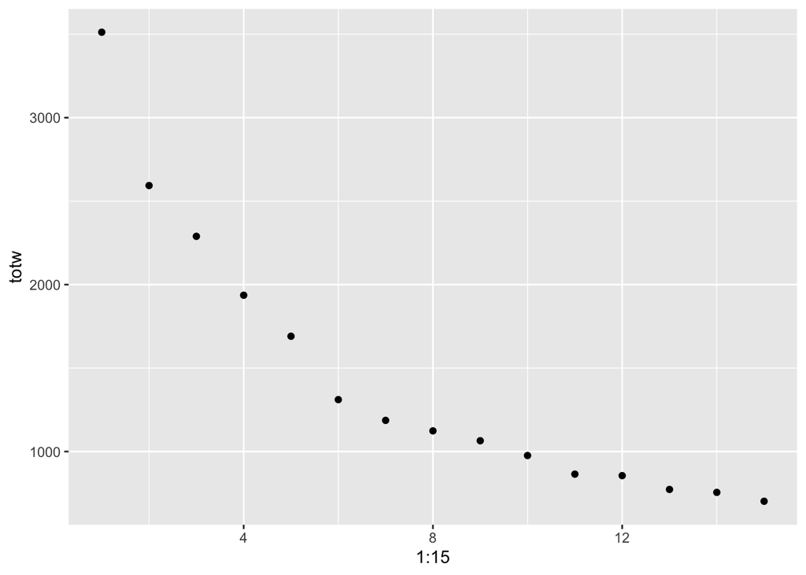

```r
totw <- sapply(1:15, find_tot_withiness)
elbow <- tibble(1:15,totw)
elbow %>%
  ggplot(aes(x = `1:15`,y=totw)) +
  geom_point()
```

#### silhouette

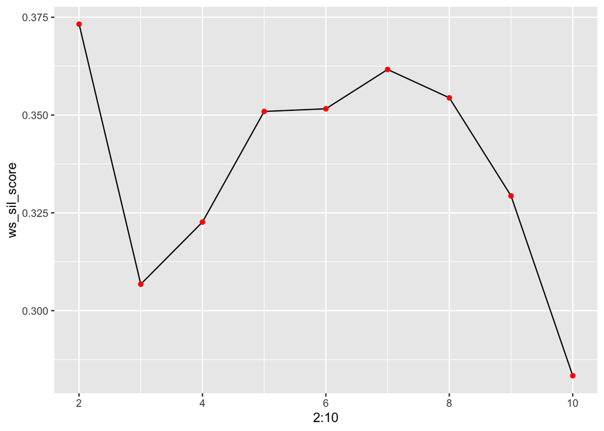

```r
set.seed(7)
library(cluster)
silhouette_score <- function(x){
  return (mean(silhouette(x, dist(dfs))[,3]))
}
ws_sil_score <- sapply(2:10, function(y){
  ws_kn <- kmeans(dfs, y)
  silhouette_score(ws_kn$cluster)
  })

tibble(2:10,ws_sil_score ) %>%
  ggplot( aes(x = `2:10`, y = ws_sil_score, group = 1)) +
  geom_line() +
  geom_point( color = 'red')
```

From figure above we can see scores are zig-zag between 2-9. Score is the highest when k = 7 from 4-7, therefore k = 7 is picked for this problem.

```r
set.seed(2)
ws_k7 <- kmeans(dfs, 7)
ws_k7$centers
```

```
##      Channel     Region       Fresh        Milk    Grocery      Frozen
## 1  1.4470045  0.3316897  1.07553954  5.10330749  5.6319063 -0.08979632
## 2  1.4470045 -0.4921002 -0.49858411  1.35187247  1.7413484 -0.28096904
## 3 -0.6895122  0.3092282  2.06220947  0.06847113 -0.1043057  2.47170679
## 4  1.4470045  0.3881943 -0.21703577  0.20493740  0.3447267 -0.33310998
## 5 -0.6895122  0.5899967  1.96458102  5.16961846  1.2857533  6.89275382
## 6 -0.5923978 -1.5968070 -0.04565930 -0.34888646 -0.3988653  0.01797471
## 7 -0.6895122  0.5899967 -0.06037912 -0.37501187 -0.4708935 -0.11842311
##   Detergents_Paper  Delicassen
## 1        5.6823687  0.41981740
## 2        1.8171058  0.33268631
## 3       -0.3616461  0.76235156
## 4        0.3691752 -0.02677043
## 5       -0.5542311 16.45971129
## 6       -0.4221272 -0.15806789
## 7       -0.4477173 -0.16801233
```

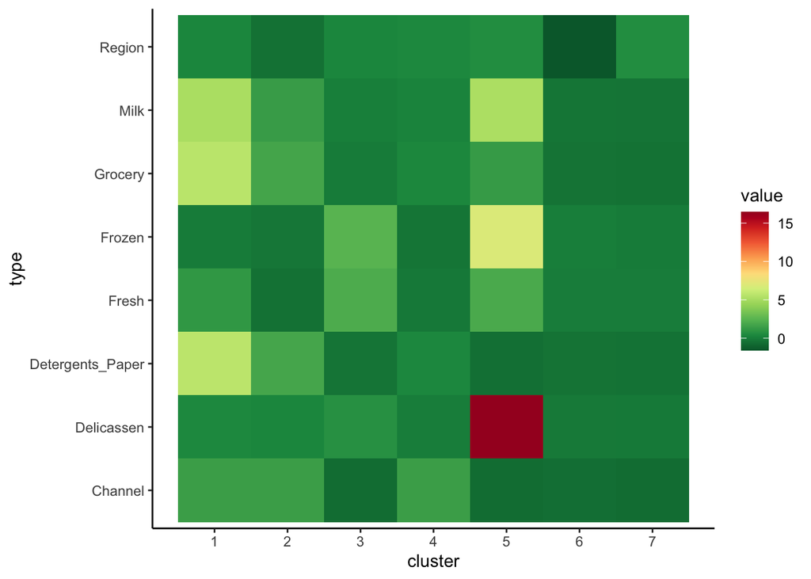

```r
library(RColorBrewer)
hm.palette <-colorRampPalette(rev(brewer.pal(10, 'RdYlGn')),space='Lab')
center_df <- data.frame(cluster=1:7,ws_k7$center)
center_df %>%
  pivot_longer(cols = -cluster,
               names_to = 'type',
               values_to = 'value') %>%
  ggplot(aes(x = type, y = cluster, fill = value)) +
    scale_y_continuous(breaks = seq(1, 7, by = 1)) +
    geom_tile() +
    coord_equal() +
    scale_fill_gradientn(colours = hm.palette(70)) +
    theme_classic() +
    coord_flip()
```

From heat map above we can see group 5 is extremely interesting that it includes the most Delicassen compared to others, and Frozen amd milk. We may say that this group people wouldn’t like to cook meals by themselves.

Since 16 is really an outlier in our heatmap, I replace it by the mean value in Delicassen for group 5 for better visualization.

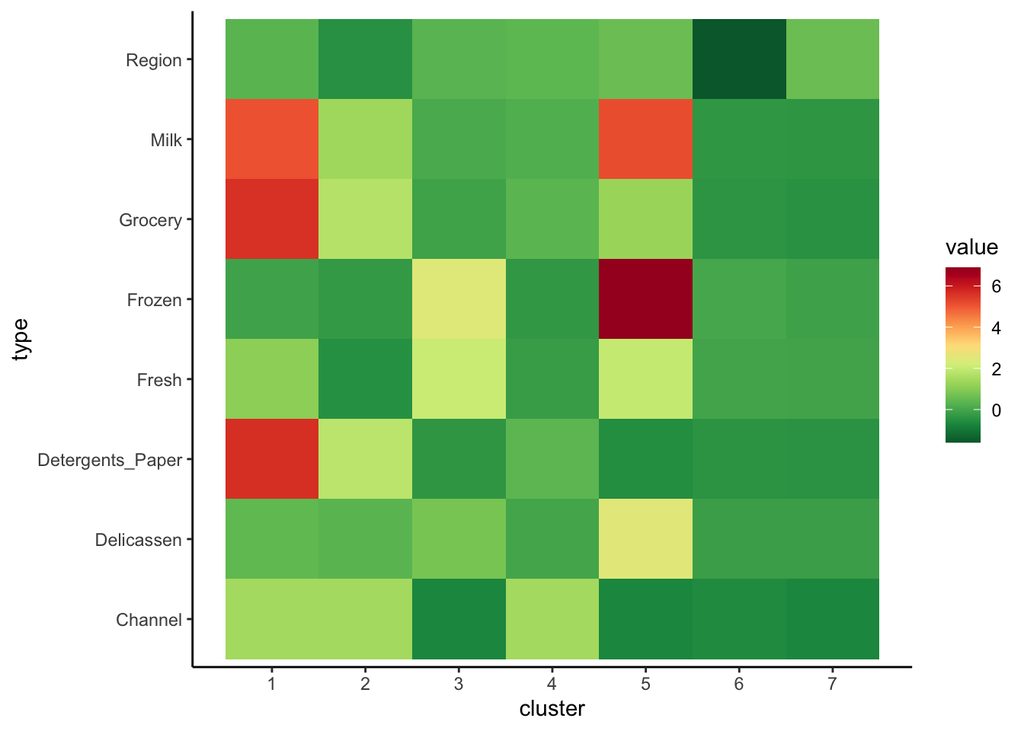

```r
center_df2 <- center_df
center_df2[5,9] <- mean(center_df2[,9])
center_df2 %>%
  pivot_longer(cols = -cluster,
               names_to = 'type',
               values_to = 'value') %>%
  ggplot(aes(x = type, y = cluster, fill = value)) +
    scale_y_continuous(breaks = seq(1, 7, by = 1)) +
    geom_tile() +
    coord_equal() +
    scale_fill_gradientn(colours = hm.palette(70)) +
    theme_classic() +
    coord_flip()
```

Group 3 and Group 4 are reversed in their buying hobbits - almost.